# eta-theta-graph

# $\eta$-$\theta$グラフ

連結無向グラフ$G$があったとき、あるノードをルートとし、ポセットを作り、そのポセットに対応して、$G$上の一様確率質量分布に対する$\eta$,$\theta$座標を算出し、それを、そのポセットの『中心$\eta$座標』『中心$\theta$座標』と呼ぶことにする。

今、$G$のすべてのノードについて『中心$\eta$座標』『中心$\theta$座標』を算出し、その座標をノードの座標と看做すと、$G$が、『座標付きグラフ』となる。

これを、$G$の$\eta$-グラフ、$G_\eta$、$G$の$\theta$-グラフ、$G_\theta$と呼ぶことにする。

$G_\eta$,$G_\theta$について、何かしらのスカラー量をとることを考える。

もし、オリジナルの$G$が閉曲面グラフであったなら、$G_\eta,G_\theta$の表面積はそのようなスカラー量である。

このスカラー量は何かしら$G$の対称性を表している可能性がある。

なぜならば、$G$がどのノードをルートにとっても同じポセット構造をもたらすような、高度な対象性を持っているとき、$G_\eta,G_\theta$のすべてのノードの座標は同一となり、このスカラー量はゼロになり(かと思ったが、これは嘘)、もし、$G$がルートノードの取り方に関して非対称であれば、このスカラー量はゼロから正の方向にずれるからである。

# まず、$G$から全ノードの『中心$\eta$座標』『中心$\theta$座標』を返す関数を作る

```r
library(igraph)
# グラフgに対して、ルートノードrhoのためのゼータ行列を返す関数
my.zeta <- function(g,rho){
  D_rho <- distances(g,v=rho)
  A <- as.matrix(get.adjacency(g))
  A_poset <- A
  for(i in 1:nv){
    for(j in 1:nv){
      if(D_rho[i] >= D_rho[j]){
        A_poset[i,j] <- 0
      }
    }
  }
  g_poset <- graph.adjacency(A_poset)
  zeta <- distances(g_poset,mode="out")
  zeta[which(is.infinite(zeta))] <- 0
  zeta <- matrix(zeta>0,nv,nv) + 0
  diag(zeta) <- 1
  return(zeta)
}
# rhoをルートに取ったときの『中心eta, theta座標』を返す関数
my.etaTheta.coords<- function(g,rho){
  zeta <- my.zeta(g,rho)
  nv <- length(V(g))
  P <- rep(1/nv,nv) # 中心は一様確率質量分布
  eta <- zeta %*% P
  theta <- solve(zeta) %*% log(P)
  return(list(eta=eta,theta=theta))
}
# ルートノードを取り替えて、それぞれの『中心eta, theta座標』を返す関数
my.etaTheta.coords.list <- function(g){
  nv <- length(V(g))
  thetas <- etas <- matrix(0,nv,nv)
  for(i in 1:nv){
    tmp <- my.etaTheta.coords(g,i)
    thetas[,i] <- tmp$theta
    etas[,i] <- tmp$eta
  }
  return(list(etas=etas,thetas=thetas))
}
```

# $G_\eta$,$G_\theta$スカラー量

```r
my.edge.len <- function(g,coords){
  el <- get.edgelist(g)
  #print(el)
  e.len <- rep(0,length(coords[,1]))
  for(i in 1:length(e.len)){
    e.len[i] <- sqrt(sum((coords[,el[i,1]] - coords[,el[i,2]])^2))
  }
  return(list(elsum =sum(e.len),elen = e.len))
}
```

# お試し

ランダムにグラフを作る。

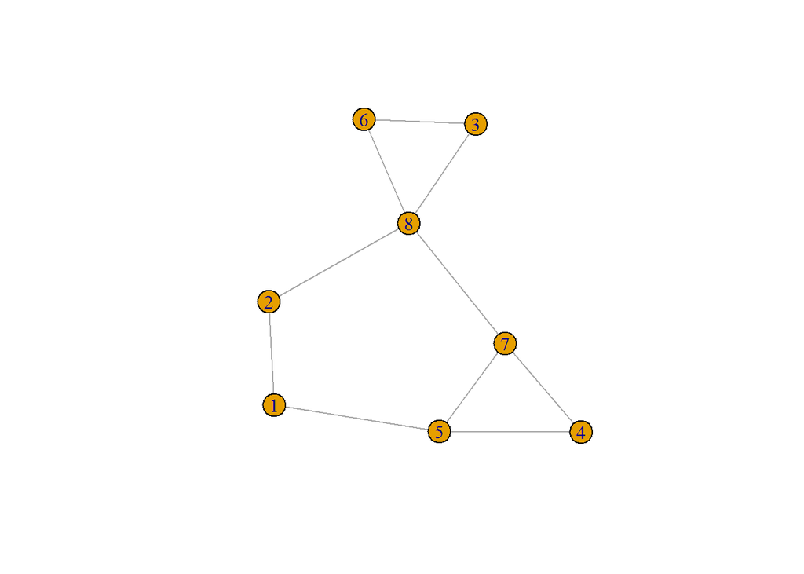

```r
nv <- 8
loop <- TRUE
while(loop){
  t <- runif(1) + 1
  A <- matrix(runif(nv^2),nv,nv)
  A <- A + t(A)
  diag(A) <- 0
  A <- matrix(A > t, nv,nv) + 0
  g <- graph.adjacency(A,mode="undirected")
  if(is.connected(g)){
    loop <- FALSE
  }
}
plot(g)
eta.theta.center <- my.etaTheta.coords.list(g)
```

```r
eta.theta.center
```

```
## $etas
##       [,1]  [,2]  [,3]  [,4]  [,5]  [,6]  [,7]  [,8]
## [1,] 1.000 0.375 0.125 0.250 0.250 0.125 0.125 0.125
## [2,] 0.500 1.000 0.250 0.125 0.125 0.250 0.125 0.250
## [3,] 0.125 0.125 1.000 0.125 0.125 0.125 0.125 0.125
## [4,] 0.125 0.125 0.125 1.000 0.125 0.125 0.125 0.125
## [5,] 0.375 0.250 0.125 0.375 1.000 0.125 0.250 0.125
## [6,] 0.125 0.125 0.125 0.125 0.125 1.000 0.125 0.125
## [7,] 0.125 0.250 0.375 0.625 0.500 0.375 1.000 0.375
## [8,] 0.375 0.625 0.750 0.500 0.375 0.750 0.500 1.000
##
## $thetas
##           [,1]      [,2]      [,3]      [,4]      [,5]      [,6]      [,7]
## [1,]  2.079442  0.000000 -2.079442  0.000000  0.000000 -2.079442 -2.079442
## [2,]  0.000000  0.000000  0.000000 -2.079442 -2.079442  0.000000 -2.079442
## [3,] -2.079442 -2.079442  2.079442 -2.079442 -2.079442 -2.079442 -2.079442
## [4,] -2.079442 -2.079442 -2.079442  0.000000 -2.079442 -2.079442 -2.079442
## [5,]  2.079442  0.000000 -2.079442  0.000000  4.158883 -2.079442  0.000000
## [6,] -2.079442 -2.079442 -2.079442 -2.079442 -2.079442  2.079442 -2.079442
## [7,] -2.079442  0.000000  2.079442  0.000000  0.000000  2.079442  4.158883
## [8,]  2.079442  4.158883  2.079442  4.158883  2.079442  2.079442  4.158883
##           [,8]
## [1,] -2.079442
## [2,]  0.000000
## [3,] -2.079442
## [4,] -2.079442
## [5,] -2.079442
## [6,] -2.079442
## [7,]  2.079442
## [8,]  6.238325
```

```r
qr(eta.theta.center$etas)
```

```
## $qr
##             [,1]        [,2]         [,3]        [,4]        [,5]
## [1,] -1.26243812 -1.01490123 -0.618842214 -0.69310328 -0.74261066
## [2,]  0.39605902 -0.82042702 -0.510479623 -0.28530097 -0.14787852
## [3,]  0.09901475  0.05875937 -1.088379469 -0.37653512 -0.25492231
## [4,]  0.09901475  0.05875937  0.059641894 -1.08952168 -0.41898389
## [5,]  0.29704426  0.02391843 -0.005532993  0.19951663 -0.83770727
## [6,]  0.09901475  0.05875937  0.059641894  0.04798869  0.05459653
## [7,]  0.09901475  0.21111905  0.244100570  0.45135513  0.33465987
## [8,]  0.29704426  0.48099748  0.432993384  0.17265214  0.09178316
##             [,6]       [,7]        [,8]
## [1,] -0.61884221 -0.5074506 -0.60646537
## [2,] -0.51047962 -0.4006910 -0.58292516
## [3,] -0.38492537 -0.4279744 -0.42976483
## [4,] -0.24311143 -0.4999390 -0.23085928
## [5,] -0.09247427 -0.3301769 -0.06448826
## [6,] -0.98424980 -0.1513707 -0.24407604
## [7,]  0.12746109 -0.6383844 -0.15835836
## [8,]  0.34208394  0.1128873  0.49683497
##
## $rank
## [1] 8
##
## $qraux
## [1] 1.792118 1.844476 1.863589 1.851093 1.936268 1.930985 1.993608 0.496835
##
## $pivot
## [1] 1 2 3 4 5 6 7 8
##
## attr(,"class")
## [1] "qr"
```

```r
elen.eta <- my.edge.len(g,eta.theta.center$etas)
elen.theta <- my.edge.len(g,eta.theta.center$thetas)
```

```r
elen.eta
```

```
## $elsum
## [1] 7.98464
##
## $elen
## [1] 0.8569568 1.1110243 0.8926786 1.2374369 0.9100137 1.0897247 0.9682458
## [8] 0.9185587
```

```r
elen.theta
```

```
## $elsum
## [1] 41.00266
##
## $elen
## [1] 4.158883 4.158883 4.158883 5.881549 5.881549 5.093571 5.093571 6.575772
```

# 対象的なグラフでやってみる

円周状のグラフ

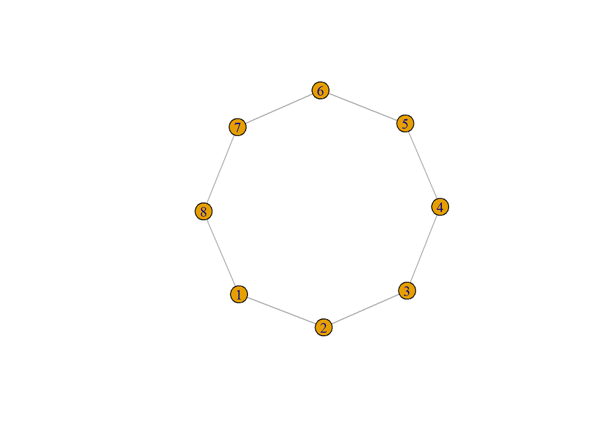

```r
ad <- diag(rep(1,nv))
ad <- ad[c(2:nv,1),]
g2 <- graph.adjacency(ad,mode="undirected")
plot(g2)
```

```r
eta.theta.center2 <- my.etaTheta.coords.list(g2)
elen.eta2 <- my.edge.len(g2,eta.theta.center2$etas)
elen.theta2 <- my.edge.len(g2,eta.theta.center2$thetas)
```

```r
qr(eta.theta.center2$etas)
```

```
## $qr
##             [,1]        [,2]        [,3]       [,4]       [,5]        [,6]
## [1,] -1.38631706 -1.17217053 -1.01437834 -0.8565862 -0.7438774 -0.85658615
## [2,]  0.36066785 -0.74019677 -0.58899961 -0.5433487 -0.4263039 -0.03672667
## [3,]  0.27050089  0.32048940 -0.73891207 -0.5901452 -0.5421267 -0.40189568
## [4,]  0.18033393  0.26995094  0.32443731 -0.7379946 -0.5911151 -0.56284691
## [5,]  0.09016696  0.21941248  0.28282766  0.3268160 -0.7372028 -0.57184061
## [6,]  0.18033393 -0.06779709  0.18033654  0.2804124  0.3242058 -0.61763083
## [7,]  0.27050089 -0.01725863 -0.11638906  0.1789373  0.2837330  0.26131015
## [8,]  0.36066785  0.03327983 -0.07477941 -0.1180692  0.1869737  0.21002015
##              [,7]        [,8]
## [1,] -1.014378339 -1.17217053
## [2,]  0.002059439 -0.04359146
## [3,] -0.004736144  0.03681053
## [4,] -0.429436126 -0.03417796
## [5,] -0.537356952 -0.40249230
## [6,] -0.332367532 -0.26873590
## [7,] -0.556101480 -0.20852551
## [8,]  0.204870641  0.51552494
##
## $rank
## [1] 8
##
## $qraux
## [1] 1.7213357 1.8776499 1.8735498 1.8766991 1.8828516 1.9421298 1.9787891
## [8] 0.5155249
##
## $pivot
## [1] 1 2 3 4 5 6 7 8
##
## attr(,"class")
## [1] "qr"
```

```r
elen.eta2
```

```
## $elsum
## [1] 6.164414
##
## $elen
## [1] 0.7705518 0.7705518 0.7705518 0.7705518 0.7705518 0.7705518 0.7705518
## [8] 0.7705518
```

```r
elen.theta2
```

```
## $elsum
## [1] 23.5262
##
## $elen
## [1] 2.940774 2.940774 2.940774 2.940774 2.940774 2.940774 2.940774 2.940774
```

```r
eta.theta.center2
```

```
## $etas
##       [,1]  [,2]  [,3]  [,4]  [,5]  [,6]  [,7]  [,8]
## [1,] 1.000 0.500 0.375 0.250 0.125 0.250 0.375 0.500
## [2,] 0.500 1.000 0.500 0.375 0.250 0.125 0.250 0.375
## [3,] 0.375 0.500 1.000 0.500 0.375 0.250 0.125 0.250
## [4,] 0.250 0.375 0.500 1.000 0.500 0.375 0.250 0.125
## [5,] 0.125 0.250 0.375 0.500 1.000 0.500 0.375 0.250
## [6,] 0.250 0.125 0.250 0.375 0.500 1.000 0.500 0.375
## [7,] 0.375 0.250 0.125 0.250 0.375 0.500 1.000 0.500
## [8,] 0.500 0.375 0.250 0.125 0.250 0.375 0.500 1.000
##
## $thetas
##           [,1]      [,2]      [,3]      [,4]      [,5]      [,6]      [,7]
## [1,]  0.000000  0.000000  0.000000  0.000000 -2.079442  0.000000  0.000000
## [2,]  0.000000  0.000000  0.000000  0.000000  0.000000 -2.079442  0.000000
## [3,]  0.000000  0.000000  0.000000  0.000000  0.000000  0.000000 -2.079442
## [4,]  0.000000  0.000000  0.000000  0.000000  0.000000  0.000000  0.000000
## [5,] -2.079442  0.000000  0.000000  0.000000  0.000000  0.000000  0.000000
## [6,]  0.000000 -2.079442  0.000000  0.000000  0.000000  0.000000  0.000000
## [7,]  0.000000  0.000000 -2.079442  0.000000  0.000000  0.000000  0.000000
## [8,]  0.000000  0.000000  0.000000 -2.079442  0.000000  0.000000  0.000000
##           [,8]
## [1,]  0.000000
## [2,]  0.000000
## [3,]  0.000000
## [4,] -2.079442
## [5,]  0.000000
## [6,]  0.000000
## [7,]  0.000000
## [8,]  0.000000
```